# EPA’s Ambient Air Monitoring

Anaïs Ladoy

27.04.2018

```r
# LIBRARIES

library(tidyverse) #Set of packages that work in harmony for data representations and API design (ggplot2, dplyr, readr, etc)

library(sf) #Package for Simple Features, way to encode spatial vector data. Binds to GDAL for reading/writing of data, GEOS for geometrical operations and PROJ for projection conversions/datum transformations (http://strimas.com/r/tidy-sf/)

library(tmap)

library(USAboundaries) #Boundaries for geographical units in the United States of America (U.S. Census Bureau)

library(tidyr) #Use to reshape dataframe

library(lubridate) #Handle dates/time series

library(forcats) #Handle factors
```

# 1. Informations about the design of the USA’s ambient air monitoring network

The monitoring network used to assess ambient air quality is operated by state and local (county) agencies and the Environmental Protection Agency (EPA) provides oversight. EPA controls, among other things, the IT infrastructure through the maintenance of data repositories available through the AQS and AirNow platforms and fix the minimum national monitoring requirements. The costs for routine monitoring are shared between the federal agency (60%) and the state (40%). The ambient monitoring network is designed by state and local agency and must be able to provide air pollution data to the public in a timely manner, to support compliance with the NAAQS, emissions strategy development and air pollution research studies.

Thereby, the Code of Federal Regulation defines three parameters that must be take into account when designing a monitoring network : the station type, the monitoring objective and the desired spatial scale of representativeness.

### Station type

#### State or Local Ambient Monitoring Station (SLAMS)

- **National Core multi-pollutant monitoring station (NCore) :** The federal regulation require sites that measure multi-pollutant including $CO$, $NO/NO_y$, $SO_2$, $O_3$, $PM_{10}$, speciated $PM_{2.5}$, $PM_{2.5}$, and $PM_{10-2.5}$ both neighbourhood and urban scale. They aim to provide support to integrated air quality management data needs used for air quality trend analyses, model evaluation and tracking metropolitan area statistics. As such, continuous monitoring methods are to be used and the sites must be placed away from direct emission sources.
- **Photochemical Assessment Monitoring Station (PAMS) :** According to federal legislation, state and local monitoring agencies are required to collect and report PAMS measurements at each NCore site located in a CBSA with a population of 1,000,000 or more (Milwaukee and Chicago for Illinois). The PAMS measurements (hourly averaged speciated VOCs, $O_3$, $NO$, mixing-height, ultraviolet radiation, etc.) aim to obtain more informations about ozone and its precursors.
- **Chemical Speciation Network (CSN) :** Each state must conduct chemical speciation monitoring and analyses at sites designated to be part of the PM2.5 Speciation Trends Network (STN). The aim is to provide informations about the chemical species that compose fine particulate, which is needed to develop State implementation plans and for atmospheric or health effects related studies.

#### Special Purpose Monitor (SPM)

SPM stations can be included in an agency’s monitoring network and in the AQS but cannot be count in the minimum requirements for the number and siting of monitors of various types needed to NAAQS compliance.

### Monitoring objectives

A monitoring network must be able to capture the maximum variability of the air pollution in a specific area with a minimal number of nodes. That is why the sites are characterised according to the type of air quality information they will provide. Specifically, we are interested about peak air pollution levels, typical levels in populated areas to assess the population exposure, air pollution transported into and outside of a city or region, and air pollution levels near specific sources.

- **Highest concentration :** Site located to determine the highest concentration expected to occur in the area covered by the network.
- **Source impact :** Site located to determine the impact of significant sources or source categories on air quality.
- **Population oriented :** Site located to measure typical concentrations in areas of high population density.
- **General background :** Site located to determine general background concentration levels.
- **Regional transport :** Site located to determine the extent of regional pollutant transport among populated areas and in support of secondary standards.
- **Welfare-related impact :** Site located to measure air pollution impacts on visibility, vegetation damage, or other welfare-based impacts.

### Spatial scale of representativeness

The spatial scale of representativeness is described in terms of the physical dimensions of the air parcel nearest to a monitoring site throughout which actual pollutant concentrations are reasonably similar.

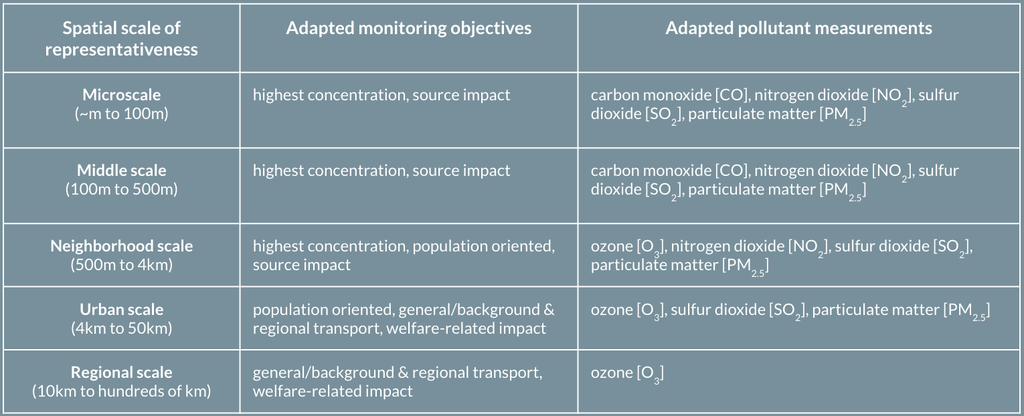

*Fig.1:* *Monitoring objective and pollutant that are adapted for a specific spatial scale of representativeness*

# 2. Definition of the study area

```r
#Absolute path of the MS locations in the FTP server
locfile <- 'Data/AirNow/monitoring_site_locations.dat'

#Metadata on MonitoringSiteFactSheet.pdf
fieldnames <- c("AQSID","parameter.name","site.code","site.name","status","agency.id","agency.name","EPA.region","latitude","longitude","elevation","GMT.offset","country.code","CMSA.code","CMSA.name","MSA.code","MSA.name","state.code","state.name","county.code","county.name","city.code","city.name")

#Read the .dat file in a tibble dataframe. Tibbles are modern data frames that keep the useful features of the traditional data frames and drop ones that were frustating (e.g. character vectors to factor, show only columns that fit to the screen when printing, etc.)
MS <- read_delim(locfile, delim='|', col_names = fieldnames, progress = TRUE)
print(MS)
```

```
## # A tibble: 10,110 x 23
##    AQSID  parameter.name site.code site.name status agency.id agency.name
##    <chr>  <chr>          <chr>     <chr>     <chr>  <chr>     <chr>
##  1 17115… O3             0013      DECATUR   Active IL1       Illinois EPA
##  2 17115… PM2.5          0013      DECATUR   Active IL1       Illinois EPA
##  3 17115… RWD            0013      DECATUR   Active IL1       Illinois EPA
##  4 17117… O3             0002      NILWOOD   Active IL1       Illinois EPA
##  5 17143… O3             0024      PEORIA_F  Active IL1       Illinois EPA
##  6 17167… O3             0010      SPFLD_PH  Inact… IL1       Illinois EPA
##  7 18011… O3             0001      Whitesto… Active IN4       Indiana Dep…
##  8 18063… O3             0004      Avon      Active IN4       Indiana Dep…
##  9 18069… O3             0002      Roanoke … Active IN4       Indiana Dep…
## 10 18071… O3             0001      Brownsto… Active IN4       Indiana Dep…
## # ... with 10,100 more rows, and 16 more variables: EPA.region <chr>,
## #   latitude <dbl>, longitude <dbl>, elevation <dbl>, GMT.offset <dbl>,
## #   country.code <chr>, CMSA.code <chr>, CMSA.name <chr>, MSA.code <int>,
## #   MSA.name <chr>, state.code <chr>, state.name <chr>, county.code <chr>,
## #   county.name <chr>, city.code <chr>, city.name <chr>
```

```r
#List of parameters measured
MS.chems <- unique(MS$parameter.name)
print(paste('In total, there are',length(MS.chems),'parameters measured',sep=' '))
```

```
## [1] "In total, there are 27 parameters measured"
```

```r
print(MS.chems)
```

```
##  [1] "O3"       "PM2.5"    "RWD"      "TEMP"     "RHUM"     "SO2"
##  [7] "RWS"      "BARPR"    "PM10"     "WS"       "WD"       "PRECIP"
## [13] "NOY"      "NO"       "SRAD"     "NOX"      "NO2"      "CO"
## [19] "NO2Y"     "BC"       "UV-AETH"  "PMC"      "H2S"      "DEWPOINT"
## [25] "SO2-15"   "PM2.5-15" "SO4"
```

```r
#List of stations
MS.stat <- unique(MS$AQSID)
print(paste('In total, there are',length(MS.stat),'different stations',sep=' '))
```

```
## [1] "In total, there are 2738 different stations"
```

```r
#MS locations

#Extract stations measuring ozone (MS.chems=O3) and particulate matter (MS.chems=PM2.5)
MS <- filter(MS,parameter.name %in% c('PM2.5','O3'))

#Convert the data frame to a spatial data frame and project the coordinates in USA Contiguous Albers Equal Area Conic (EPSG:102003)
MS <- st_as_sf(MS, coords = c('longitude','latitude'), agr = 'identity', crs=4326) %>% st_transform(MS, crs=102003)

#Visualisation of PM2.5 and O3 MS (different colors for active/inactive MS)
# tmap_mode("view")
# tm_shape(us_counties()) + tm_borders(col='black', lty=2) +
#   tm_shape(us_states()) + tm_borders(col='black', lwd=2) +
#   tm_shape(MS[MS$parameter.name=='PM2.5',],name='PM2.5 MS locations') +          tm_dots(col='status',palette=c('blue','red')) +
#   tm_shape(MS[MS$parameter.name=='O3',],name='O3 MS locations') + tm_dots(col='status',palette=c('blue','red'),legend.show=FALSE)
```

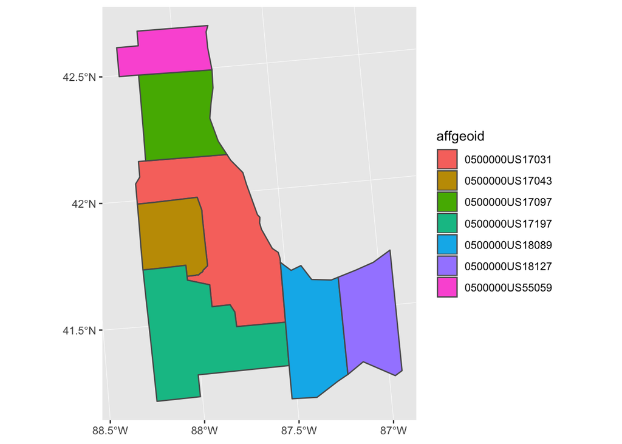

```r
#CREATE TWO DATAFRAMES : counties to store all the counties we want to keep, MS to store all the monitoring stations belonging to the counties

#include neighboring counties of Chicago and also Lake and Porter from Indiana (lot of industries)

counties <- us_counties() %>% filter(state_name %in% c('Illinois','Indiana','Wisconsin') & name %in% c('Cook','Lake','DuPage','Will','Porter','Kenosha')) %>% st_transform(counties, crs=102003)

#Sites measuring O3 and PM2.5 at the 6 counties we're interested in
MS <- MS[which(st_intersects(MS,counties) > 0),]

#Same MS for PM2.5 and O3
MS.both<-group_by(MS,by=AQSID) %>% summarise(length=n()) %>% filter(length==2) %>% .[['by']]

#Plot the counties included in the MS location
ggplot(counties,aes(fill = affgeoid)) + geom_sf()
```

```r
#Add metadata about the Monitoring Stations (Type, Objectives, ...) from the different states documents (Illinois, Indiana, Wisconsin). Informations for Wisconsin and Indiana will be added manually (only a few stations)
path_docs <- '/Volumes/GoogleDrive/My Drive/PDM/Docs/'

MS <- read_csv(paste0(path_docs,'meta_O3_MS.csv'),col_names = TRUE,na = c("N/A", "NA")) %>% rbind(read_csv(paste0(path_docs,'meta_PM25_MS.csv'),col_names = TRUE,na = c("N/A", "NA"))) %>% mutate(AQSID = gsub(pattern='-',replacement = '',x=AQSID)) %>% merge(x=MS,by=c('AQSID','parameter.name'),all.x=TRUE)

MS <- MS %>% select(AQSID,site.name.x,parameter.name,status,state.name,county.name,primary.objective,secondary.objective,spatial.scale,station.type) %>% rename(site.name=site.name.x)

#Overwrite if one layer already exists
st_write(counties,'Data/Spatial/counties.shp',delete_layer = TRUE)
```

```
## Deleting layer `counties' using driver `ESRI Shapefile'
## Writing layer `counties' to data source `/Volumes/GoogleDrive/My Drive/PDM/R/Data/Spatial/counties.shp' using driver `ESRI Shapefile'
## features:       7
## fields:         12
## geometry type:  Multi Polygon
```

# 3. Extraction of the EPA’s data for $O_{3}$ and $PM_{2.5}$ and data cleaning/wrangling

```r
#READ DATA FOR ALL YEARS

yeardir <- 'Data/AirNow/DailyPeak'
yearfiles <- list.files(yeardir,full.names=TRUE)
fieldnames <- c("vdate","AQSID","site.name","parameter.name","report.units",
                "value","avg.period","agency.name")

#Function to extract the desired data (Ozone-8h and PM2.5-24h) for a given file
extract_data <- function(file) {
  return(read_delim(file, "|", col_names = fieldnames, progress = FALSE) %>% filter(AQSID %in% unique(MS$AQSID)) %>% filter(parameter.name=='OZONE-8HR' | parameter.name=='PM2.5-24hr'))
}

#For loop to go over all the files in the directory
data <- data.frame()

for(j in 1:length(yearfiles)) {
  datadir <- paste0(yeardir,substr(yearfiles[j],nchar(yearfiles[j])-4,nchar(yearfiles[j])))
  datfiles <- list.files(datadir,full.names=TRUE)

  for(i in 1:length(datfiles))
  {
  res <- extract_data(datfiles[i])
  data <- rbind(data,res)
  }
}
```

```r
#DATA WRANGLING
data.bckp <- data
#data <- data.bckp

data_wrangling <- function(df) {

  #Keep only useful fields (time, AQSID, parameter, values)
  df <- select(df,c('vdate','AQSID','parameter.name','value'))

  #Convert to tidy format (spread parameter name)
  df <- spread(df, key='parameter.name', value='value')

  #Change name of columns
  names(df) <- c('date','AQSID','O3','PM25')

  #Data conversion
  df$date<-mdy(df$date) #date from char to date
  df$AQSID<-factor(df$AQSID) #AQSID from char to factor

  return(df)
}

#Data wrangling process
data <- data_wrangling(data)

#Make appear missing dates explicitely using complete() from tidyr
data <- complete(data,date = seq.Date(min(date), max(date), by="day"))

#Print implicit missing values
missingD <- filter(data, is.na(O3) & is.na(PM25)) %>% .[['date']] %>% format("%Y%m%d")
print(missingD) #Dates with missing data
```

```
##  [1] "20151230" "20170818" "20170819" "20170820" "20170821" "20170822"
##  [7] "20170823" "20170824" "20170825" "20170826" "20170827" "20170828"
## [13] "20170829" "20170830" "20170831" "20170901" "20170902" "20170903"
## [19] "20170904" "20170905"
```

```r
#Extract missing data in http://files.airnowtech.org/ if possible
extract_missingD <- function(missingD) {

  df<-data.frame()

  for (i in 1:length(missingD)) {

  df_sub <- read.delim(paste0("https://s3-us-west-1.amazonaws.com//files.airnowtech.org/airnow/",substr(missingD[i],1,4),"/",missingD[i],"/daily_data.dat"), sep="|", header=FALSE, col.names = fieldnames) %>% filter(AQSID %in% unique(MS$AQSID)) %>% filter(parameter.name=='OZONE-8HR' | parameter.name=='PM2.5-24hr') #Extract data and filter to only have the wanted MS and parameters (PM2.5/O3)

  df <- rbind(df,df_sub)
  }

  return(df)
}

#Extract missing data
missingD.data <- extract_missingD(missingD)

#Rearrange the results according to the wrangling process
missingD.data <- data_wrangling(missingD.data)

#Check if the daily_data.dat is daily peak values by using the same function to extract known informations
missingD.test <- sample_n(data, 10) #Take 10 random rows of the initial dataframe
missingD.test.data <- extract_missingD(format(missingD.test$date,"%Y%m%d")) #Extract values on files.airnowtech.org
missingD.test.data<- data_wrangling(missingD.test.data) #Reshape the resulting dataframe

missingD.comp<-inner_join(missingD.test,missingD.test.data,by=c('date','AQSID'))
#print(missingD.comp$O3.x==missingD.comp$O3.y)
#print(missingD.comp$PM25.x==missingD.comp$PM25.y)
#daily_data.dat corresponds to daily peak values

#Bind retrieved missing values to dataframe
data <- data %>% drop_na(AQSID) #Remove the rows added to detect missing values
data <- rbind(data,missingD.data)

#Number of missing values still missing
print(nrow(complete(data,date = seq.Date(min(date), max(date), by="day")))-nrow(data))
```

```
## [1] 0
```

```r
#Number of observations we're supposed to have for a complete time series (nb of days between the first and last day as daily measurements)
nbDays<-as.numeric(max(data$date) - min(data$date))
```

```
## $x
## [1] "Date"
##
## $y
## [1] "O3 [ppb]"
##
## attr(,"class")
## [1] "labels"
```

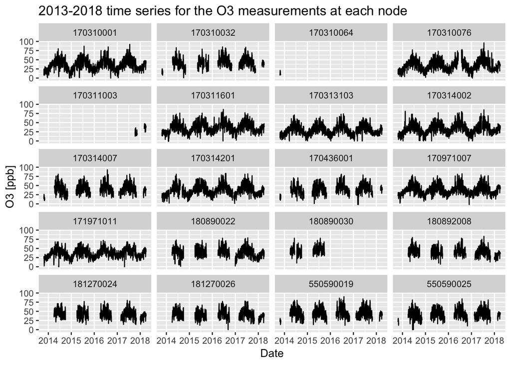

```r
#EXPLORATORY DATA ANALYSIS of Ozone

MS.O3 <- filter(MS,parameter.name=='O3') %>% select(-parameter.name) #monitoring stations measuring O3
data.O3 <- data %>% filter(AQSID %in% MS.O3[['AQSID']]) %>% subset(select = -PM25) #subset of the dataframe keep only the MS recording O3 (the ones in MS.O3)

data.O3 <- data.O3 %>% droplevels() %>% complete(date,AQSID) #complete the dataframe with the missing combinaisons (data,AQSID) of data in order to make explicite the missing values
MS.O3 <- data.O3 %>% group_by(AQSID) %>% summarize(nb_na = sum(is.na(O3)), mean_val = mean(O3, na.rm=TRUE)) %>% full_join(MS.O3, by='AQSID') #count the nb of missing observations (obs=dailyPeak record) per node

data.O3 %>% ggplot(aes(x=date, y=O3)) + geom_line() + facet_wrap(~AQSID, nrow=5) + ggtitle('2013-2018 time series for the O3 measurements at each node') + labs(x='Date',y='O3 [ppb]') %>% print() #time series for each O3 monitoring station
```

```r
MS.O3 <- MS.O3 %>% mutate(group=ifelse(nb_na < 0.1*nbDays, '>90%', ifelse(nb_na > 0.8*nbDays, '<20%', '20%-90%'))) #create groups according the different type of data frequency as noticed in the time series diagnostic
pal.typeData <- c('<20%'='#f66253','>90%'='#86b24f','20%-90%'='#f6a760') #create a color palette corresponding to these groups

print(MS.O3)
```

```
## # A tibble: 21 x 13
##    AQSID     nb_na mean_val site.name status   state.name county.name
##    <chr>     <int>    <dbl> <chr>     <chr>    <chr>      <chr>
##  1 170310001    53     35.8 ALSIP     Active   IL         COOK
##  2 170310032   759     42.4 CHI_SWFP  Active   IL         COOK
##  3 170310064  1616     13.7 CHI_U     Inactive IL         COOK
##  4 170310076   109     34.6 CHI_COM   Active   IL         COOK
##  5 170311003  1573     31.8 CHI_TAFT  Active   IL         COOK
##  6 170311601    63     36.2 LEMONT    Active   IL         COOK
##  7 170313103    55     29.6 SCHILPRK  Active   IL         COOK
##  8 170314002    43     33.1 CICERO    Active   IL         COOK
##  9 170314007   652     40.9 DESPLNS   Active   IL         COOK
## 10 170314201   101     37.0 NORTHBRK  Active   IL         COOK
## # ... with 11 more rows, and 6 more variables: primary.objective <chr>,
## #   secondary.objective <chr>, spatial.scale <chr>, station.type <chr>,
## #   geometry <POINT [m]>, group <chr>
```

```r
# ggplot() + geom_sf(data=counties) + geom_sf(data=MS.O3,aes(color=group)) + scale_colour_manual(values = pal.typeData,na.value='black') + ggtitle('O3 monitoring stations') + labs(colour='Time series completeness') + theme_void() #plot the O3 monitoring stations according the data frequency they have

write_csv(data.O3,'Data/CSV/data_O3.csv')
```

```r
#EXPLORATORY DATA ANALYSIS of PM2.5

MS.PM25 <- filter(MS,parameter.name=='PM2.5') %>% select(-parameter.name) #monitoring stations measuring PM2.5
data.PM25 <- data %>% filter(AQSID %in% MS.PM25[['AQSID']]) %>% subset(select = -O3) #subset of the dataframe keep only the MS recording PM2.5 (the ones in MS.PM25)

data.PM25 <- data.PM25 %>% droplevels() %>% complete(date,AQSID) #complete the dataframe with the missing combinaisons (data,AQSID) of data in order to make explicite the missing values
MS.PM25 <- data.PM25 %>% group_by(AQSID) %>% summarize(nb_na = sum(is.na(PM25))) %>% full_join(MS.PM25, by='AQSID') #count the nb of missing observations (obs=dailyPeak record) per node

print(MS.PM25)
```

```
## # A tibble: 16 x 11
##    AQSID  nb_na site.name   status state.name county.name primary.objecti…
##    <chr>  <int> <chr>       <chr>  <chr>      <chr>       <chr>
##  1 17031…   130 ALSIP       Active IL         COOK        Population
##  2 17031…   377 CHI_SP      Active IL         COOK        Population
##  3 17031…   144 CHI_COM     Active IL         COOK        Population
##  4 17031…  1178 DESPLNS     Active IL         COOK        Population
##  5 17031…   502 NORTHBRK    Active IL         COOK        Population
##  6 17031…   307 Cicero2     Active IL         COOK        Population
##  7 17043…  1443 Naperville  Active IL         DU PAGE     Population
##  8 17197…  1537 Joliet      Active IL         WILL        Population
##  9 17197…   126 BRAIDWD     Active IL         WILL        Background
## 10 18089…   194 Gary-IITRI  Active IN         LAKE        Source
## 11 18089…  1585 Hammond-16… Active IN         LAKE        <NA>
## 12 18089…  1501 Hammond-Pu… Inact… IN         LAKE        Population
## 13 18127…   118 Ogden Dunes Active IN         PORTER      Population
## 14 55059…    70 CHIWAUKEE   Active WI         KENOSHA     Regional Transp…
## 15 17031…    NA CHI_WASH    Inact… IL         COOK        Population
## 16 17031…    NA MAYWOOD2    Inact… IL         COOK        <NA>
## # ... with 4 more variables: secondary.objective <chr>,
## #   spatial.scale <chr>, station.type <chr>, geometry <POINT [m]>
```

```
## $x
## [1] "Date"
##
## $y
## [1] "PM2.5 [ug/m3]"
##
## attr(,"class")
## [1] "labels"
```

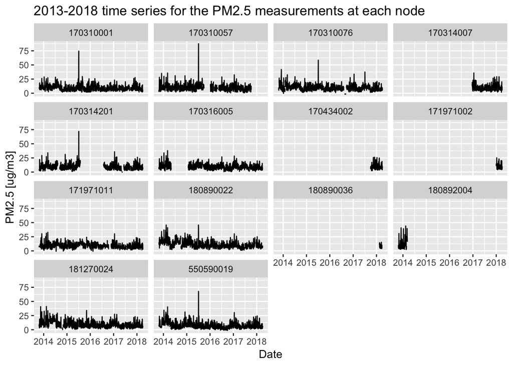

```r
data.PM25 %>% ggplot(aes(x=date, y=PM25)) + geom_line() + facet_wrap(~AQSID, nrow=4) + ggtitle('2013-2018 time series for the PM2.5 measurements at each node') + labs(x='Date',y='PM2.5 [ug/m3]') %>% print() #time series for each PM2.5 monitoring station
```

```r
MS.PM25 <- MS.PM25 %>% mutate(group=ifelse(nb_na < 0.1*nbDays, '>90%', ifelse(nb_na > 0.8*nbDays, '<20%', '20%-90%'))) #create groups according the different type of data frequency as noticed in the time series diagnostic

print(MS.PM25)
```

```
## # A tibble: 16 x 12
##    AQSID  nb_na site.name   status state.name county.name primary.objecti…
##    <chr>  <int> <chr>       <chr>  <chr>      <chr>       <chr>
##  1 17031…   130 ALSIP       Active IL         COOK        Population
##  2 17031…   377 CHI_SP      Active IL         COOK        Population
##  3 17031…   144 CHI_COM     Active IL         COOK        Population
##  4 17031…  1178 DESPLNS     Active IL         COOK        Population
##  5 17031…   502 NORTHBRK    Active IL         COOK        Population
##  6 17031…   307 Cicero2     Active IL         COOK        Population
##  7 17043…  1443 Naperville  Active IL         DU PAGE     Population
##  8 17197…  1537 Joliet      Active IL         WILL        Population
##  9 17197…   126 BRAIDWD     Active IL         WILL        Background
## 10 18089…   194 Gary-IITRI  Active IN         LAKE        Source
## 11 18089…  1585 Hammond-16… Active IN         LAKE        <NA>
## 12 18089…  1501 Hammond-Pu… Inact… IN         LAKE        Population
## 13 18127…   118 Ogden Dunes Active IN         PORTER      Population
## 14 55059…    70 CHIWAUKEE   Active WI         KENOSHA     Regional Transp…
## 15 17031…    NA CHI_WASH    Inact… IL         COOK        Population
## 16 17031…    NA MAYWOOD2    Inact… IL         COOK        <NA>
## # ... with 5 more variables: secondary.objective <chr>,
## #   spatial.scale <chr>, station.type <chr>, geometry <POINT [m]>,
## #   group <chr>
```

```r
# ggplot() + geom_sf(data=counties) + geom_sf(data=MS.PM25,aes(color=group)) + scale_colour_manual(values = pal.typeData,na.value='black') + ggtitle('PM2.5 monitoring stations') + labs(colour='Time series completeness') + theme_void() #plot the O3 monitoring stations according the data frequency they have

write_csv(data.PM25,'Data/CSV/data_PM25.csv')
```

```r
tmap_mode("view")
popup.vars <- c("AQSID"="AQSID","Site Name"="site.name","State"="state.name","County"="county.name","Primary Objective"="primary.objective","Secondary Objective"="secondary.objective","Spatial Scale"="spatial.scale","Station Type"="station.type")

tm_shape(counties) + tm_borders(col='black', lty=2) +
  tm_shape(st_sf(MS.O3), name='O3 monitoring stations') + tm_dots(col='group',palette=pal.typeData,popup.vars=popup.vars) +
  tm_shape(st_sf(MS.PM25), name='PM2.5 monitoring stations') + tm_dots(col='group',palette=pal.typeData,legend.show=FALSE,popup.vars=popup.vars) + tm_layout(title='Select MS for a specific pollutant in the layer selection')
```

[interactive chart not shown]

```r
MS.PM25$spatial.scale <- factor(MS.PM25$spatial.scale,levels=c("Neighborhood","Urban","Regional", "Middle"),ordered=TRUE)
MS.O3$spatial.scale <- factor(MS.O3$spatial.scale,levels=c("Neighborhood","Urban","Regional", "Middle"),ordered=TRUE)

pal.spatialscale <- c('Neighborhood'='#d11141','Urban'='#00b159','Regional'='#00aedb','Middle'='#f37735') #create a color palette corresponding to these groups

tm_shape(counties) + tm_borders(col='black', lty=2) +
  tm_shape(st_sf(MS.PM25), name='PM2.5 monitoring stations') + tm_dots(col='spatial.scale',palette=pal.spatialscale,popup.vars=popup.vars) +
  tm_shape(st_sf(MS.O3), name='O3 monitoring stations') + tm_dots(col='spatial.scale',palette=pal.spatialscale,legend.show=FALSE,popup.vars=popup.vars) +
 tm_layout(title='Select MS for a specific pollutant in the layer selection')
```

[interactive chart not shown]

```r
# O3 : Remove CHI_U (inactive)
# Where is Evanston? Data missing
MS.O3 <- MS.O3 %>% filter(!AQSID %in% c('170310064'))

# PM2.5 : Remove CHI-WASH and MAYWOOD (inactives)
MS.PM25 <- MS.PM25 %>% filter(!AQSID %in% c('170310022','170316006'))

# Write the spatial shapefiles for the location of the monitoring stations (+metadata) for each pollutant
write_sf(st_as_sf(MS.PM25,geom=MS.PM25$geometry),'Data/Spatial/MS_PM25.shp', delete_layer = TRUE)
```

```
## ignoring columns with unsupported type:
## [1] "geomtry"
```

```r
write_sf(st_as_sf(MS.O3,geom=MS.O3$geometry),'Data/Spatial/MS_O3.shp', delete_layer = TRUE)
```

```
## ignoring columns with unsupported type:
## [1] "geomtry"
```